SAVE OUTFILE='Z:\Documents\GitHub\STISIM-Task-Analysis\SPSS Results\Driving sd lanepos.sav'  
/COMPRESSED.  
GET  
FILE='Z:\Documents\GitHub\STISIM-Task-Analysis\SPSS Results\Task_RT_wide_bothcongruency.sav'.  
DATASET NAME DataSet2 WINDOW=FRONT.  
* Encoding: UTF-8.  
EXAMINE VARIABLES=S1_R1 S1_R2 S2_R1 S2_R2  
/PLOT BOXPLOT NPPLOT  
/COMPARE GROUPS  
/STATISTICS NONE  
/CINTERVAL 95  
/MISSING LISTWISE  
/NOTOTAL.

# **Explore**

NotesNotes, table, 0 levels of column headers and 2 levels of row headers, table with 3 columns and 14 rows

| Output Created |  | 15-APR-2019 23:56:22 |
| --- | --- | --- |
| Comments |  |  |
| Input | Data | Z:\Documents\GitHub\STISIM-Task-Analysis\SPSS Results\Task_RT_wide_bothcongruency.sav |
|  | Active Dataset | DataSet2 |
|  | Filter | <none> |
|  | Weight | <none> |
|  | Split File | <none> |
|  | N of Rows in Working Data File | 13 |
| Missing Value Handling | Definition of Missing | User-defined missing values for dependent variables are treated as missing. |
|  | Cases Used | Statistics are based on cases with no missing values for any dependent variable or factor used. |
| Syntax |  | EXAMINE VARIABLES=S1_R1 S1_R2 S2_R1 S2_R2 /PLOT BOXPLOT NPPLOT /COMPARE GROUPS /STATISTICS NONE /CINTERVAL 95 /MISSING LISTWISE /NOTOTAL. |
| Resources | Processor Time | 00:00:02.23 |
|  | Elapsed Time | 00:00:02.24 |

[DataSet2] Z:\Documents\GitHub\STISIM-Task-Analysis\SPSS Results\Task_RT_wide_bothcongruency.sav

Case Processing SummaryCase Processing Summary, table, 3 levels of column headers and 1 levels of row headers, table with 7 columns and 8 rows

|  | Cases |  |  |  |  |  |
| --- | --- | --- | --- | --- | --- | --- |
|  | Valid |  | Missing |  | Total |  |
|  | N | Percent | N | Percent | N | Percent |
| S1_R1 | 12 | 92.3% | 1 | 7.7% | 13 | 100.0% |
| S1_R2 | 12 | 92.3% | 1 | 7.7% | 13 | 100.0% |
| S2_R1 | 12 | 92.3% | 1 | 7.7% | 13 | 100.0% |
| S2_R2 | 12 | 92.3% | 1 | 7.7% | 13 | 100.0% |

Tests of NormalityTests of Normality, table, 2 levels of column headers and 1 levels of row headers, table with 7 columns and 9 rows

|  | Kolmogorov-Smirnov<sup>a</sup> |  |  | Shapiro-Wilk |  |  |
| --- | --- | --- | --- | --- | --- | --- |
|  | Statistic | df | Sig. | Statistic | df | Sig. |
| S1_R1 | .145 | 12 | .200* | .941 | 12 | .505 |
| S1_R2 | .178 | 12 | .200* | .944 | 12 | .549 |
| S2_R1 | .143 | 12 | .200* | .933 | 12 | .409 |
| S2_R2 | .234 | 12 | .070 | .934 | 12 | .430 |

*. This is a lower bound of the true significance.  
a. Lilliefors Significance Correction

# **S1_R1**

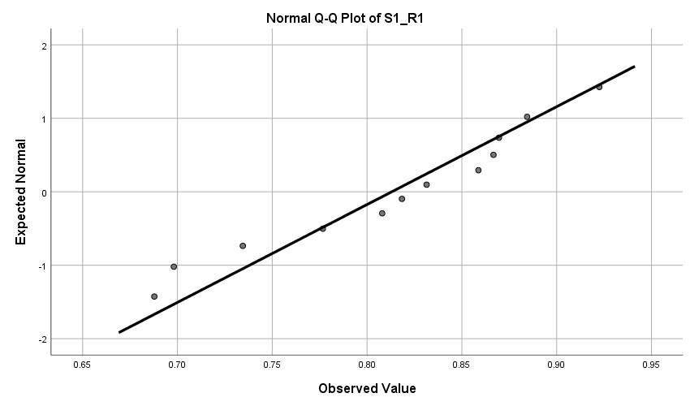

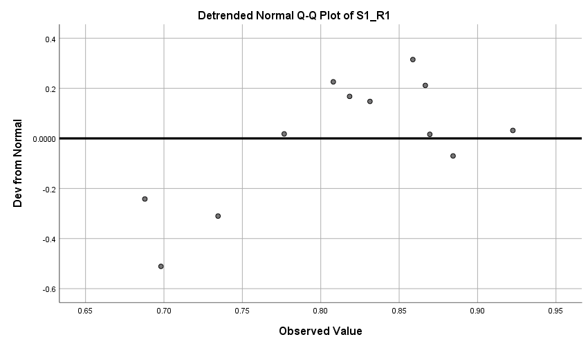

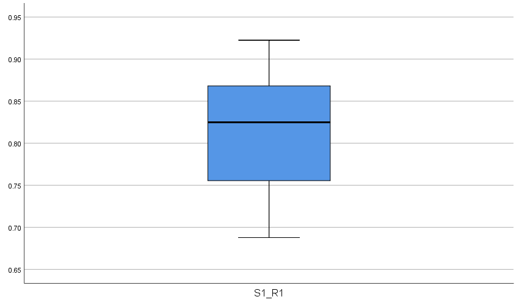

# **S1_R2**

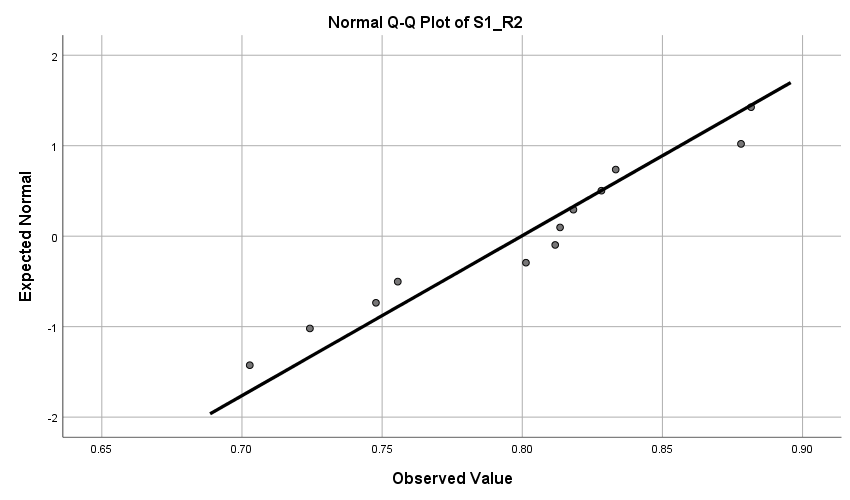

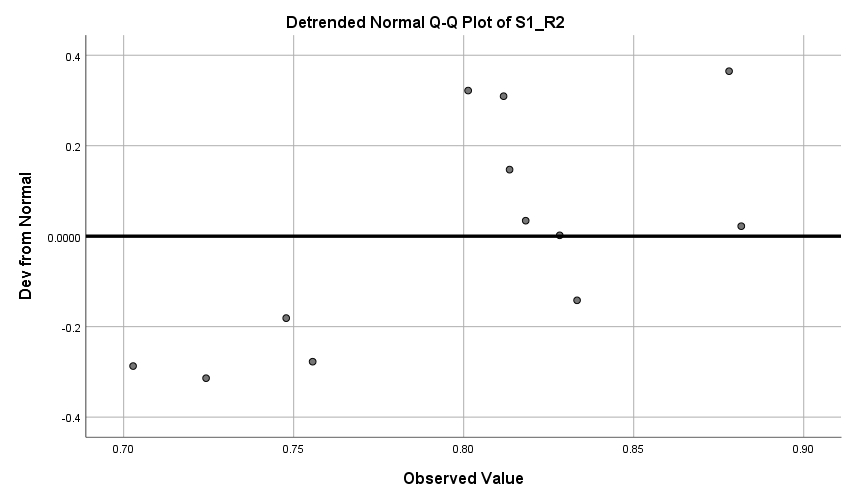

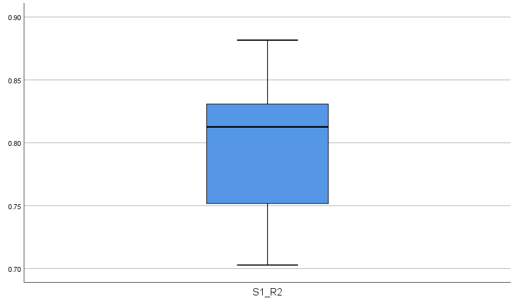

# **S2_R1**

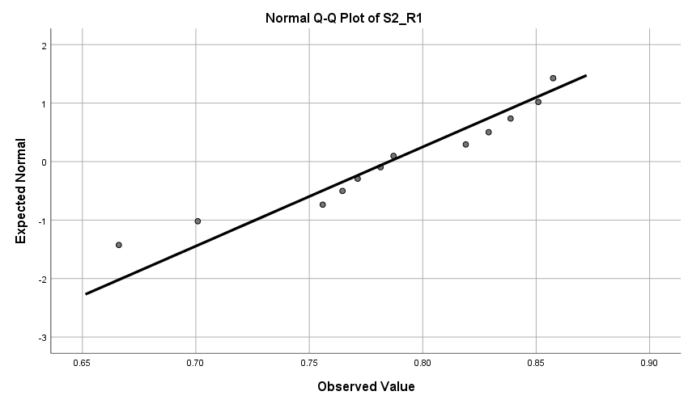

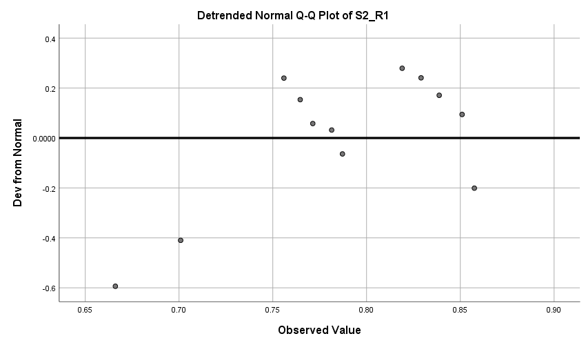

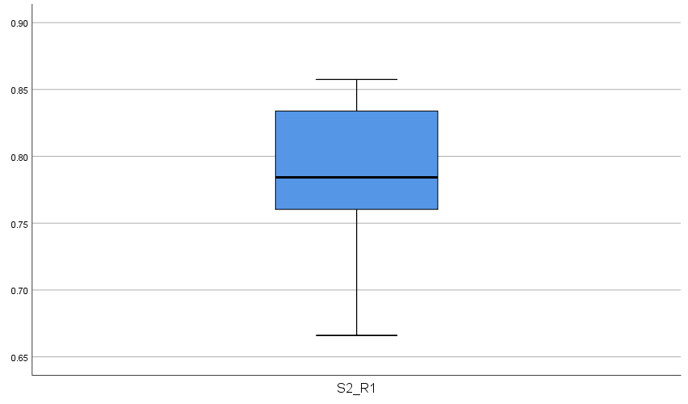

# **S2_R2**

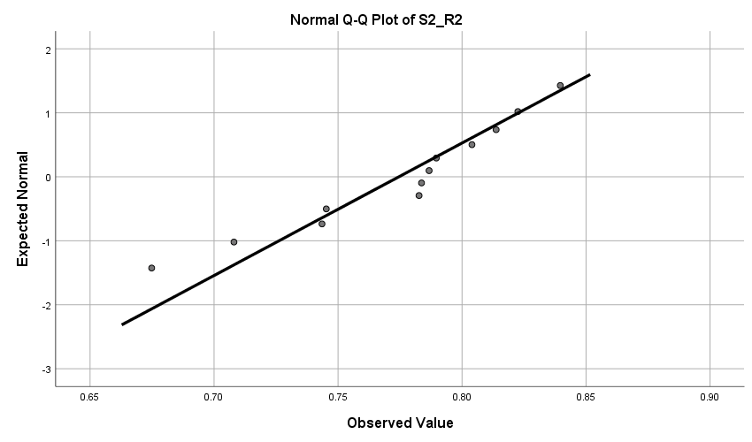

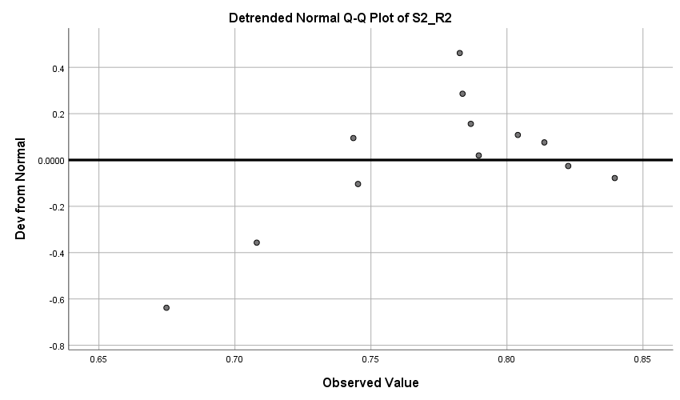

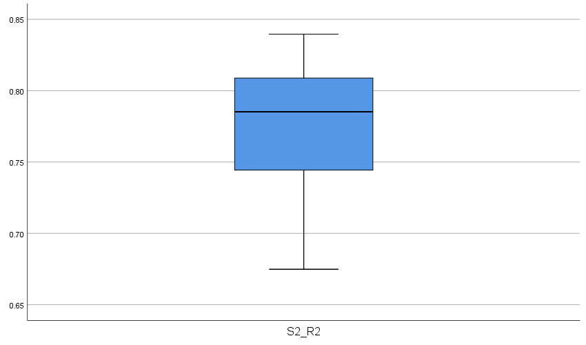

T-TEST PAIRS=S1_R1 S2_R1 S1_R2 WITH S1_R2 S2_R2 S2_R2 (PAIRED)  
/CRITERIA=CI(.9500)  
/MISSING=ANALYSIS.

# **T-Test**

NotesNotes, table, 0 levels of column headers and 2 levels of row headers, table with 3 columns and 14 rows

| Output Created |  | 15-APR-2019 23:56:25 |
| --- | --- | --- |
| Comments |  |  |
| Input | Data | Z:\Documents\GitHub\STISIM-Task-Analysis\SPSS Results\Task_RT_wide_bothcongruency.sav |
|  | Active Dataset | DataSet2 |
|  | Filter | <none> |
|  | Weight | <none> |
|  | Split File | <none> |
|  | N of Rows in Working Data File | 13 |
| Missing Value Handling | Definition of Missing | User defined missing values are treated as missing. |
|  | Cases Used | Statistics for each analysis are based on the cases with no missing or out-of-range data for any variable in the analysis. |
| Syntax |  | T-TEST PAIRS=S1_R1 S2_R1 S1_R2 WITH S1_R2 S2_R2 S2_R2 (PAIRED) /CRITERIA=CI(.9500) /MISSING=ANALYSIS. |
| Resources | Processor Time | 00:00:00.00 |
|  | Elapsed Time | 00:00:00.04 |

Paired Samples StatisticsPaired Samples Statistics, table, 1 levels of column headers and 2 levels of row headers, table with 6 columns and 8 rows

|  |  | Mean | N | Std. Deviation | Std. Error Mean |
| --- | --- | --- | --- | --- | --- |
| Pair 1 | S1_R1 | .820510 | 13 | .0767520 | .0212872 |
|  | S1_R2 | .805633 | 13 | .0582403 | .0161529 |
| Pair 2 | S2_R1 | .785209 | 12 | .0589877 | .0170283 |
|  | S2_R2 | .774508 | 12 | .0482904 | .0139402 |
| Pair 3 | S1_R2 | .805633 | 13 | .0582403 | .0161529 |
|  | S2_R2 | .779723 | 13 | .0499111 | .0138429 |

Paired Samples CorrelationsPaired Samples Correlations, table, 1 levels of column headers and 2 levels of row headers, table with 5 columns and 5 rows

|  |  | N | Correlation | Sig. |
| --- | --- | --- | --- | --- |
| Pair 1 | S1_R1 & S1_R2 | 13 | .911 | .000 |
| Pair 2 | S2_R1 & S2_R2 | 12 | .953 | .000 |
| Pair 3 | S1_R2 & S2_R2 | 13 | .944 | .000 |

Paired Samples TestPaired Samples Test, table, 3 levels of column headers and 2 levels of row headers, table with 10 columns and 7 rows

[output not shown]

COMPUTE logS1_R1=LG10(S1_R1).  
EXECUTE.  
COMPUTE logS1_R2=LG10(S1_R2).  
EXECUTE.  
COMPUTE logS2_R1=LG10(S2_R1).  
EXECUTE.  
COMPUTE logS2_R2=LG10(S2_R2).  
EXECUTE.  
EXAMINE VARIABLES=logS1_R1 logS1_R2 logS2_R1 logS2_R2  
/PLOT NPPLOT  
/STATISTICS NONE  
/CINTERVAL 95  
/MISSING LISTWISE  
/NOTOTAL.

# **Explore**

NotesNotes, table, 0 levels of column headers and 2 levels of row headers, table with 3 columns and 14 rows

| Output Created |  | 15-APR-2019 23:56:25 |
| --- | --- | --- |
| Comments |  |  |
| Input | Data | Z:\Documents\GitHub\STISIM-Task-Analysis\SPSS Results\Task_RT_wide_bothcongruency.sav |
|  | Active Dataset | DataSet2 |
|  | Filter | <none> |
|  | Weight | <none> |
|  | Split File | <none> |
|  | N of Rows in Working Data File | 13 |
| Missing Value Handling | Definition of Missing | User-defined missing values for dependent variables are treated as missing. |
|  | Cases Used | Statistics are based on cases with no missing values for any dependent variable or factor used. |
| Syntax |  | EXAMINE VARIABLES=logS1_R1 logS1_R2 logS2_R1 logS2_R2 /PLOT NPPLOT /STATISTICS NONE /CINTERVAL 95 /MISSING LISTWISE /NOTOTAL. |
| Resources | Processor Time | 00:00:01.52 |
|  | Elapsed Time | 00:00:01.43 |

Case Processing SummaryCase Processing Summary, table, 3 levels of column headers and 1 levels of row headers, table with 7 columns and 8 rows

|  | Cases |  |  |  |  |  |
| --- | --- | --- | --- | --- | --- | --- |
|  | Valid |  | Missing |  | Total |  |
|  | N | Percent | N | Percent | N | Percent |
| logS1_R1 | 12 | 92.3% | 1 | 7.7% | 13 | 100.0% |
| logS1_R2 | 12 | 92.3% | 1 | 7.7% | 13 | 100.0% |
| logS2_R1 | 12 | 92.3% | 1 | 7.7% | 13 | 100.0% |
| logS2_R2 | 12 | 92.3% | 1 | 7.7% | 13 | 100.0% |

Tests of NormalityTests of Normality, table, 2 levels of column headers and 1 levels of row headers, table with 7 columns and 9 rows

|  | Kolmogorov-Smirnov<sup>a</sup> |  |  | Shapiro-Wilk |  |  |
| --- | --- | --- | --- | --- | --- | --- |
|  | Statistic | df | Sig. | Statistic | df | Sig. |
| logS1_R1 | .157 | 12 | .200* | .928 | 12 | .357 |
| logS1_R2 | .191 | 12 | .200* | .939 | 12 | .489 |
| logS2_R1 | .157 | 12 | .200* | .920 | 12 | .284 |
| logS2_R2 | .243 | 12 | .049 | .922 | 12 | .300 |

*. This is a lower bound of the true significance.  
a. Lilliefors Significance Correction

# **logS1_R1**

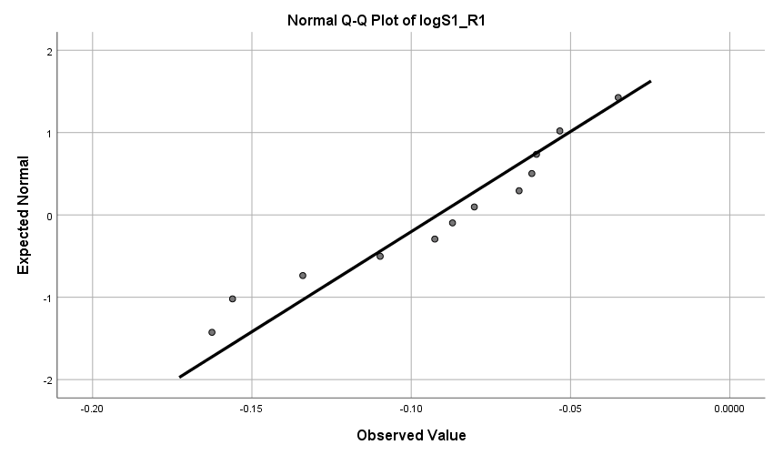

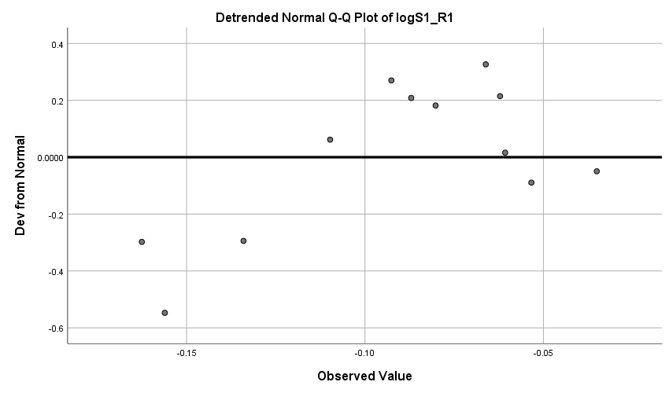

# **logS1_R2**

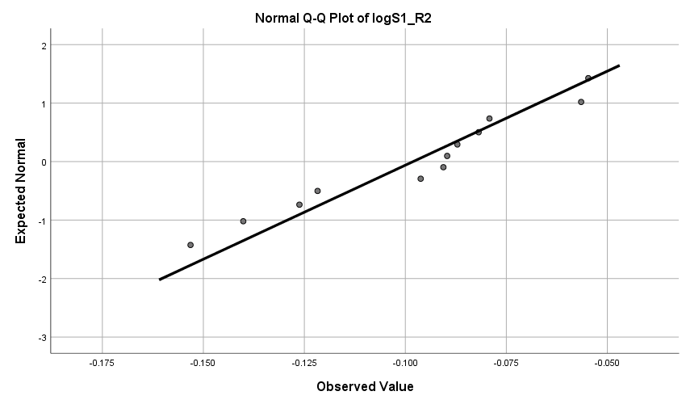

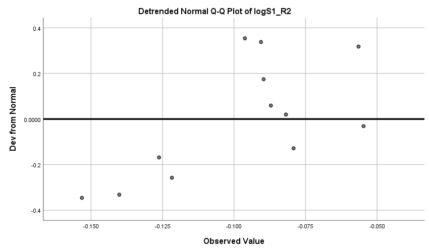

# **logS2_R1**

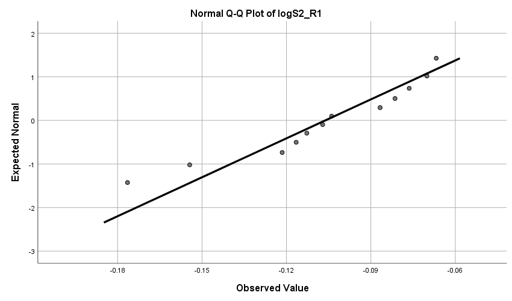

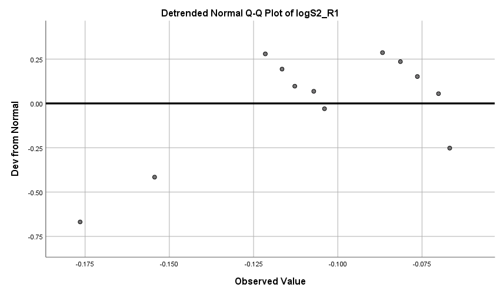

# **logS2_R2**

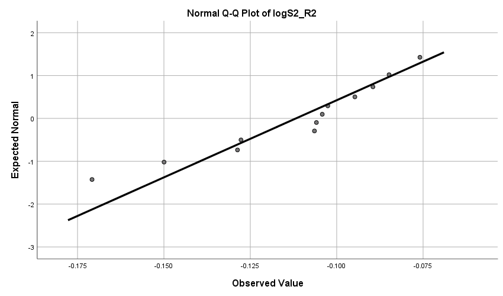

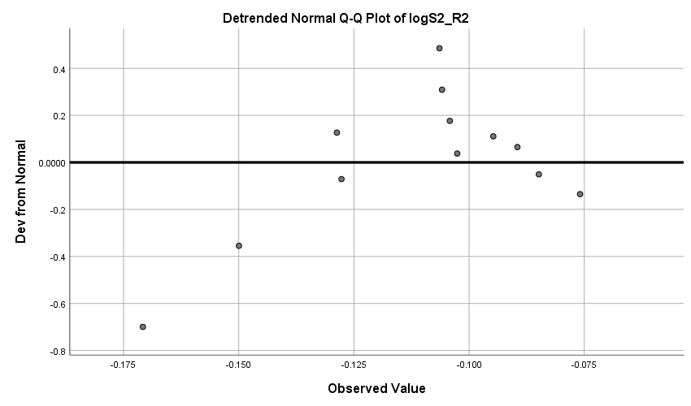

T-TEST PAIRS=logS1_R1 logS2_R1 logS1_R2 WITH logS1_R2 logS2_R2 logS2_R2 (PAIRED)  
/CRITERIA=CI(.9500)  
/MISSING=ANALYSIS.

# **T-Test**

NotesNotes, table, 0 levels of column headers and 2 levels of row headers, table with 3 columns and 14 rows

| Output Created |  | 15-APR-2019 23:56:27 |
| --- | --- | --- |
| Comments |  |  |
| Input | Data | Z:\Documents\GitHub\STISIM-Task-Analysis\SPSS Results\Task_RT_wide_bothcongruency.sav |
|  | Active Dataset | DataSet2 |
|  | Filter | <none> |
|  | Weight | <none> |
|  | Split File | <none> |
|  | N of Rows in Working Data File | 13 |
| Missing Value Handling | Definition of Missing | User defined missing values are treated as missing. |
|  | Cases Used | Statistics for each analysis are based on the cases with no missing or out-of-range data for any variable in the analysis. |
| Syntax |  | T-TEST PAIRS=logS1_R1 logS2_R1 logS1_R2 WITH logS1_R2 logS2_R2 logS2_R2 (PAIRED) /CRITERIA=CI(.9500) /MISSING=ANALYSIS. |
| Resources | Processor Time | 00:00:00.00 |
|  | Elapsed Time | 00:00:00.00 |

Paired Samples StatisticsPaired Samples Statistics, table, 1 levels of column headers and 2 levels of row headers, table with 6 columns and 8 rows

|  |  | Mean | N | Std. Deviation | Std. Error Mean |
| --- | --- | --- | --- | --- | --- |
| Pair 1 | logS1_R1 | -.0877 | 13 | .04181 | .01160 |
|  | logS1_R2 | -.0949 | 13 | .03187 | .00884 |
| Pair 2 | logS2_R1 | -.1062 | 12 | .03356 | .00969 |
|  | logS2_R2 | -.1118 | 12 | .02777 | .00802 |
| Pair 3 | logS1_R2 | -.0949 | 13 | .03187 | .00884 |
|  | logS2_R2 | -.1089 | 13 | .02852 | .00791 |

Paired Samples CorrelationsPaired Samples Correlations, table, 1 levels of column headers and 2 levels of row headers, table with 5 columns and 5 rows

|  |  | N | Correlation | Sig. |
| --- | --- | --- | --- | --- |
| Pair 1 | logS1_R1 & logS1_R2 | 13 | .919 | .000 |
| Pair 2 | logS2_R1 & logS2_R2 | 12 | .957 | .000 |
| Pair 3 | logS1_R2 & logS2_R2 | 13 | .948 | .000 |

Paired Samples TestPaired Samples Test, table, 3 levels of column headers and 2 levels of row headers, table with 10 columns and 7 rows

[output not shown]

*Nonparametric Tests: Related Samples.  
NPTESTS  
/RELATED TEST(S1_R1 S1_R2) WILCOXON  
/MISSING SCOPE=ANALYSIS USERMISSING=EXCLUDE  
/CRITERIA ALPHA=0.05 CILEVEL=95.

# **Nonparametric Tests**

NotesNotes, table, 0 levels of column headers and 2 levels of row headers, table with 3 columns and 12 rows

| Output Created |  | 15-APR-2019 23:56:27 |
| --- | --- | --- |
| Comments |  |  |
| Input | Data | Z:\Documents\GitHub\STISIM-Task-Analysis\SPSS Results\Task_RT_wide_bothcongruency.sav |
|  | Active Dataset | DataSet2 |
|  | Filter | <none> |
|  | Weight | <none> |
|  | Split File | <none> |
|  | N of Rows in Working Data File | 13 |
| Syntax |  | NPTESTS /RELATED TEST(S1_R1 S1_R2) WILCOXON /MISSING SCOPE=ANALYSIS USERMISSING=EXCLUDE /CRITERIA ALPHA=0.05 CILEVEL=95. |
| Resources | Processor Time | 00:00:00.13 |
|  | Elapsed Time | 00:00:00.08 |

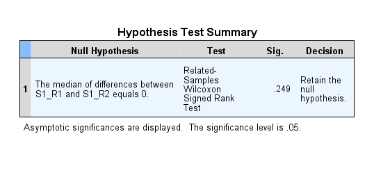

*Nonparametric Tests: Related Samples.  
NPTESTS  
/RELATED TEST(S2_R1 S2_R2) WILCOXON  
/MISSING SCOPE=ANALYSIS USERMISSING=EXCLUDE  
/CRITERIA ALPHA=0.05 CILEVEL=95.

# **Nonparametric Tests**

NotesNotes, table, 0 levels of column headers and 2 levels of row headers, table with 3 columns and 12 rows

| Output Created |  | 15-APR-2019 23:56:27 |
| --- | --- | --- |
| Comments |  |  |
| Input | Data | Z:\Documents\GitHub\STISIM-Task-Analysis\SPSS Results\Task_RT_wide_bothcongruency.sav |
|  | Active Dataset | DataSet2 |
|  | Filter | <none> |
|  | Weight | <none> |
|  | Split File | <none> |
|  | N of Rows in Working Data File | 13 |
| Syntax |  | NPTESTS /RELATED TEST(S2_R1 S2_R2) WILCOXON /MISSING SCOPE=ANALYSIS USERMISSING=EXCLUDE /CRITERIA ALPHA=0.05 CILEVEL=95. |
| Resources | Processor Time | 00:00:00.09 |
|  | Elapsed Time | 00:00:00.08 |

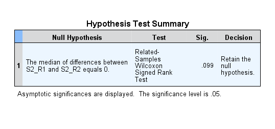

*Nonparametric Tests: Related Samples.  
NPTESTS  
/RELATED TEST(S1_R2 S2_R2) WILCOXON  
/MISSING SCOPE=ANALYSIS USERMISSING=EXCLUDE  
/CRITERIA ALPHA=0.05 CILEVEL=95.

# **Nonparametric Tests**

NotesNotes, table, 0 levels of column headers and 2 levels of row headers, table with 3 columns and 12 rows

| Output Created |  | 15-APR-2019 23:56:27 |
| --- | --- | --- |
| Comments |  |  |
| Input | Data | Z:\Documents\GitHub\STISIM-Task-Analysis\SPSS Results\Task_RT_wide_bothcongruency.sav |
|  | Active Dataset | DataSet2 |
|  | Filter | <none> |
|  | Weight | <none> |
|  | Split File | <none> |
|  | N of Rows in Working Data File | 13 |
| Syntax |  | NPTESTS /RELATED TEST(S1_R2 S2_R2) WILCOXON /MISSING SCOPE=ANALYSIS USERMISSING=EXCLUDE /CRITERIA ALPHA=0.05 CILEVEL=95. |
| Resources | Processor Time | 00:00:00.11 |
|  | Elapsed Time | 00:00:00.09 |

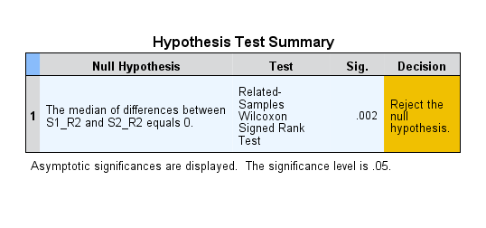